# MEDL_HW08_Soln

**Deep Learning for Mechanical Engineering**  
**Homework 08 - Solution**  
**Due Tuesday, 06/02/2020, 3:30 PM**

TA: Kangsan Lee and Namjeong Lee  
Instructor: Prof. Seungchul Lee  
http://iai.postech.ac.kr/  
Industrial AI Lab at POSTECH

- For your handwritten solution, scan or take a picture of them.
- For your code, only .ipynb file will be graded.
  - Please write your NAME and student ID on your .ipynb files. ex) KangsanLee_20202467_HW08.ipynb
- Please compress all the files to make a single .zip file
  - Please write your NAME and student ID on your .zip files. ex) NamjeongLee_20202467_HW08.zip
  - Submit it to LMS
- Do not submit a printed version of your code. It will not be graded.

# Problem 1: MNIST Digit Classification with Insufficient Data

In many real problems, lack of data is a critical issue. Especially, engineering problems rarely have fault data since they have to be collected when the system is abnoramlly operating. Thus, it is essential to train the model with a small data set. One possible method is the **transfer learning** that we learned in class.

In this problem, we are going to classify MNIST digit images with insufficient train data. First, we will train a CNN model with a small dataset. And then, we will train the same model but using transfer learning to compare both models.

For transfer learning, we will use the [EMNIST alphabet dataset](https://www.nist.gov/itl/products-and-services/emnist-dataset).

[Download alphabet dataset](https://www.dropbox.com/s/llmme9kvapgp71b/EMNIST_files.zip?dl=1)

```python
import numpy as np
import matplotlib.pyplot as plt
%matplotlib inline

import tensorflow as tf
from sklearn.model_selection import train_test_split
```

(1) Load MNIST dataset. To intentionally make data insufficient, set each digit to have around 50 data and print the number of each class.

```python
from tensorflow.examples.tutorials.mnist import input_data
mnist = input_data.read_data_sets("MNIST_data/", one_hot=True, validation_size=59500)

for i in range(10):
    print('label: {}, nums: {}'.format(i, len(np.where(np.argmax(mnist.train.labels, axis=1) == i)[0])))
```

[output not shown]

```
Successfully downloaded train-images-idx3-ubyte.gz 9912422 bytes.
Extracting MNIST_data/train-images-idx3-ubyte.gz
```

[output not shown]

```
Successfully downloaded train-labels-idx1-ubyte.gz 28881 bytes.
Extracting MNIST_data/train-labels-idx1-ubyte.gz
Successfully downloaded t10k-images-idx3-ubyte.gz 1648877 bytes.
Extracting MNIST_data/t10k-images-idx3-ubyte.gz
```

[output not shown]

```
Successfully downloaded t10k-labels-idx1-ubyte.gz 4542 bytes.
Extracting MNIST_data/t10k-labels-idx1-ubyte.gz
label: 0, nums: 46
label: 1, nums: 54
label: 2, nums: 52
label: 3, nums: 48
label: 4, nums: 51
label: 5, nums: 44
label: 6, nums: 55
label: 7, nums: 55
label: 8, nums: 46
label: 9, nums: 49
```

(2) Define a CNN model for MNIST.

```python
# input layer
input_h = 28 # Input height
input_w = 28 # Input width
input_ch = 1 # Input channel : Gray scale
# (None, 28, 28, 1)

# First convolution layer
k1_h = 3
k1_w = 3
k1_ch = 32
p1_h = 2
p1_w = 2
# (None, 14, 14 ,32)

# Second convolution layer
k2_h = 3
k2_w = 3
k2_ch = 64
p2_h = 2
p2_w = 2
# (None, 7, 7 ,64)

## Fully connected: flatten the features -> (None, 7*7*64)
conv_result_size = int(input_h/(p1_h*p2_h)) * int(input_w/(p1_w*p2_w)) * k2_ch
n_hidden = 100

# kernel size: [kernel_height, kernel_width, input_ch, output_ch]
weights = {
    'conv1' : tf.Variable(tf.random_normal([k1_h, k1_w, input_ch, k1_ch], stddev = 0.1)),
    'conv2' : tf.Variable(tf.random_normal([k2_h, k2_w, k1_ch, k2_ch], stddev = 0.1)),
    'hidden' : tf.Variable(tf.random_normal([conv_result_size, n_hidden], stddev = 0.1)),
    'output_10_1' : tf.Variable(tf.random_normal([n_hidden, 10], stddev = 0.1)),
    'output_10_2' : tf.Variable(tf.random_normal([n_hidden, 10], stddev = 0.1)),
    'output_26' : tf.Variable(tf.random_normal([n_hidden, 26], stddev = 0.1))
}

# bias size: [output_ch] or [neuron_size]
biases = {
    'conv1' : tf.Variable(tf.random_normal([k1_ch], stddev = 0.1)),
    'conv2' : tf.Variable(tf.random_normal([k2_ch], stddev = 0.1)),
    'hidden' : tf.Variable(tf.random_normal([n_hidden], stddev = 0.1)),
    'output_10_1' : tf.Variable(tf.random_normal([10], stddev = 0.1)),
    'output_10_2' : tf.Variable(tf.random_normal([10], stddev = 0.1)),
    'output_26' : tf.Variable(tf.random_normal([26], stddev = 0.1))
}

# input layer: [batch_size, image_height, image_width, channels]
# output layer: [batch_size, class_size]
x = tf.placeholder(tf.float32, [None, input_h, input_w, input_ch])
y_26 = tf.placeholder(tf.float32, [None, 26])
y_10 = tf.placeholder(tf.float32, [None, 10])

# [batch, height, width, channels]

# First convolution layer
conv1 = tf.nn.conv2d(x,
                     weights['conv1'],
                     strides = [1, 1, 1, 1],
                     padding = 'SAME')
conv1 = tf.nn.relu(tf.add(conv1, biases['conv1']))
maxp1 = tf.nn.max_pool(conv1,
                       ksize = [1, p1_h, p1_w, 1],
                       strides = [1, p1_h, p1_w, 1],
                       padding = 'VALID')

# Second convolution layer
conv2 = tf.nn.conv2d(maxp1,
                     weights['conv2'],
                     strides = [1, 1, 1, 1],
                     padding = 'SAME')
conv2 = tf.nn.relu(tf.add(conv2, biases['conv2']))
maxp2 = tf.nn.max_pool(conv2,
                       ksize = [1, p2_h, p2_w, 1],
                       strides = [1, p2_h, p2_w, 1],
                       padding = 'VALID')

maxp2_flatten = tf.reshape(maxp2, [-1, conv_result_size])

# Fully connected
hidden = tf.add(tf.matmul(maxp2_flatten, weights['hidden']), biases['hidden'])
hidden = tf.nn.relu(hidden)
pred_10_1 = tf.add(tf.matmul(hidden, weights['output_10_1']), biases['output_10_1'])
pred_10_2 = tf.add(tf.matmul(hidden, weights['output_10_2']), biases['output_10_2'])
pred_26 = tf.add(tf.matmul(hidden, weights['output_26']), biases['output_26'])

LR = 0.001

loss_10_1 = tf.reduce_mean(tf.nn.softmax_cross_entropy_with_logits_v2(labels = y_10, logits = pred_10_1))
loss_10_2 = tf.reduce_mean(tf.nn.softmax_cross_entropy_with_logits_v2(labels = y_10, logits = pred_10_2))
loss_26 = tf.reduce_mean(tf.nn.softmax_cross_entropy_with_logits_v2(labels = y_26, logits = pred_26))

optm_10_1 = tf.train.AdamOptimizer(LR).minimize(loss_10_1)
optm_10_2 = tf.train.AdamOptimizer(LR).minimize(loss_10_2, var_list=[weights['output_10_2'], biases['output_10_2']])
optm_26 = tf.train.AdamOptimizer(LR).minimize(loss_26)

def next_batch(x, y, batch_size):
    random_idx = np.random.randint(len(y), size = batch_size)
    return x[random_idx], y[random_idx]
```

(3) Train your model, plot train and test loss, and test your model. Since the model is trained with small dataset, testset accuracy might be low.

```
(0000/0250) loss_train: 2.115158, loss_test: 2.334331
(0012/0250) loss_train: 1.368232, loss_test: 1.791327
(0024/0250) loss_train: 0.675901, loss_test: 1.102161
(0036/0250) loss_train: 0.372204, loss_test: 0.919936
(0048/0250) loss_train: 0.104794, loss_test: 1.179634
(0060/0250) loss_train: 0.123586, loss_test: 1.549714
(0072/0250) loss_train: 0.089310, loss_test: 0.924273
(0084/0250) loss_train: 0.038553, loss_test: 0.727579
(0096/0250) loss_train: 0.032549, loss_test: 1.130949
(0108/0250) loss_train: 0.017954, loss_test: 0.758802
(0120/0250) loss_train: 0.014365, loss_test: 1.590899
(0132/0250) loss_train: 0.027761, loss_test: 1.151672
(0144/0250) loss_train: 0.006973, loss_test: 1.427363
(0156/0250) loss_train: 0.029154, loss_test: 1.223324
(0168/0250) loss_train: 0.011119, loss_test: 1.514234
(0180/0250) loss_train: 0.011756, loss_test: 1.327325
(0192/0250) loss_train: 0.008665, loss_test: 0.674857
(0204/0250) loss_train: 0.004842, loss_test: 0.900929
(0216/0250) loss_train: 0.003914, loss_test: 0.978443
(0228/0250) loss_train: 0.003418, loss_test: 0.798282
(0240/0250) loss_train: 0.001800, loss_test: 1.608450
```

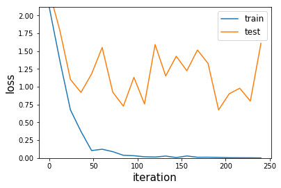

```
Accuracy_trainset : 100.0%
Accuracy_testset : 76.7%
```

```python
n_batch = 50
n_iter = 250
n_prt = n_iter//20

sess = tf.Session()
init = tf.global_variables_initializer()
sess.run(init)

loss_record_train = []
loss_record_test = []
for epoch in range(n_iter+1):
    train_x, train_y = mnist.train.next_batch(n_batch)
    train_x = np.reshape(train_x, [-1, input_h, input_w, input_ch])
    sess.run(optm_10_1, feed_dict = {x: train_x,  y_10: train_y})

    if epoch % n_prt == 0:
        test_x, test_y = mnist.test.next_batch(n_batch)
        test_x = np.reshape(test_x, [-1, input_h, input_w, input_ch])
        c1 = sess.run(loss_10_1, feed_dict = {x: train_x, y_10: train_y})
        c2 = sess.run(loss_10_1, feed_dict = {x: test_x, y_10: test_y})
        loss_record_train.append(c1)
        loss_record_test.append(c2)
        print ("({:04d}/{:04d}) loss_train: {:.6f}, loss_test: {:.6f}".format(epoch, n_iter, c1, c2))

plt.plot(np.arange(len(loss_record_train))*n_prt, loss_record_train, label = 'train')
plt.plot(np.arange(len(loss_record_test))*n_prt, loss_record_test, label = 'test')
plt.xlabel('iteration', fontsize = 15)
plt.ylabel('loss', fontsize = 15)
plt.legend(fontsize = 12)
plt.ylim([0, np.max(loss_record_train)])
plt.show()

my_pred = sess.run(pred_10_1, feed_dict = {x: mnist.train.images.reshape(-1, 28, 28, 1)})
accr = np.mean(np.equal(np.argmax(my_pred, axis = 1), np.argmax(mnist.train.labels, axis = 1)))
print("Accuracy_trainset : {:.1f}%".format(accr*100))

my_pred = sess.run(pred_10_1, feed_dict = {x: mnist.test.images.reshape(-1, 28, 28, 1)})
accr = np.mean(np.equal(np.argmax(my_pred, axis = 1), np.argmax(mnist.test.labels, axis = 1)))
print("Accuracy_testset : {:.1f}%".format(accr*100))
```

Now, we are going to apply the transfer learning. First, run the below cell to load the hand-written alphabet dataset.

```python
img_file = './data_files/Alphabet_Handwritten_1000_images.npy'
lbl_file = './data_files/Alphabet_Handwritten_1000_labels.npy'

x_total = (np.load(img_file)/255).astype(np.float32)
y_total = tf.keras.utils.to_categorical(np.load(lbl_file))

x_train, x_test, y_train, y_test = train_test_split(x_total, y_total, test_size=0.3, random_state=77)

print('Trainset shape:', x_train.shape, y_train.shape)
print('Testset shape:', x_test.shape, y_test.shape)

del x_total, y_total
```

```
Trainset shape: (18200, 784) (18200, 26)
Testset shape: (7800, 784) (7800, 26)
```

(4) Plot random images for each character.

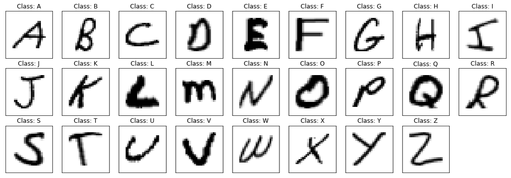

```python
plt.figure(figsize=(18, 6))
for i in range(26):
    plt.subplot(3, 9, i+1)
    r = np.random.choice(np.where(np.argmax(y_train, axis=1) == i)[0])
    plt.imshow(x_train[r].reshape(28, 28), 'gray_r')
    plt.title('Class: {}'.format(chr(65+np.argmax(y_train[r]))))
    plt.xticks([]); plt.yticks([])
plt.show()
```

(5) Initialize all weights, train the CNN model with EMNIST alphbet data, and test the model.

```
(0000/1000) loss_train: 3.132027, loss_test: 3.433800
(0050/1000) loss_train: 1.215789, loss_test: 1.177451
(0100/1000) loss_train: 0.573602, loss_test: 0.721720
(0150/1000) loss_train: 0.855209, loss_test: 0.618286
(0200/1000) loss_train: 0.580848, loss_test: 0.806354
(0250/1000) loss_train: 0.282767, loss_test: 0.457217
(0300/1000) loss_train: 0.369089, loss_test: 0.396852
(0350/1000) loss_train: 0.272427, loss_test: 0.377257
(0400/1000) loss_train: 0.242721, loss_test: 0.278954
(0450/1000) loss_train: 0.259459, loss_test: 0.241220
(0500/1000) loss_train: 0.081387, loss_test: 0.280449
(0550/1000) loss_train: 0.118953, loss_test: 0.199812
(0600/1000) loss_train: 0.180118, loss_test: 0.117183
(0650/1000) loss_train: 0.180168, loss_test: 0.389358
(0700/1000) loss_train: 0.104175, loss_test: 0.129241
(0750/1000) loss_train: 0.184105, loss_test: 0.219553
(0800/1000) loss_train: 0.114851, loss_test: 0.210537
(0850/1000) loss_train: 0.091859, loss_test: 0.092673
(0900/1000) loss_train: 0.046917, loss_test: 0.342243
(0950/1000) loss_train: 0.131357, loss_test: 0.184483
(1000/1000) loss_train: 0.068706, loss_test: 0.255189
```

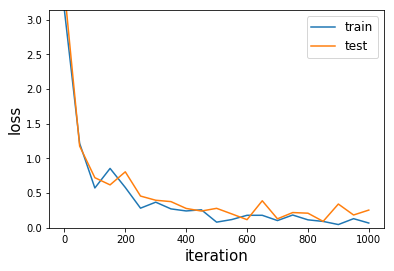

```
Accuracy_trainset : 97.1%
Accuracy_testset : 95.1%
```

```python
sess.run(init)

n_iter = 1000
n_prt = n_iter//20

loss_record_train = []
loss_record_test = []
for epoch in range(n_iter+1):
    train_x, train_y = next_batch(x_train, y_train, n_batch)
    train_x = np.reshape(train_x, [-1, input_h, input_w, input_ch])
    sess.run(optm_26, feed_dict = {x: train_x,  y_26: train_y})

    if epoch % n_prt == 0:
        test_x, test_y = next_batch(x_test, y_test, n_batch)
        test_x = np.reshape(test_x, [-1, input_h, input_w, input_ch])
        c1 = sess.run(loss_26, feed_dict = {x: train_x, y_26: train_y})
        c2 = sess.run(loss_26, feed_dict = {x: test_x, y_26: test_y})
        loss_record_train.append(c1)
        loss_record_test.append(c2)
        print ("({:04d}/{:04d}) loss_train: {:.6f}, loss_test: {:.6f}".format(epoch, n_iter, c1, c2))

plt.plot(np.arange(len(loss_record_train))*n_prt, loss_record_train, label = 'train')
plt.plot(np.arange(len(loss_record_test))*n_prt, loss_record_test, label = 'test')
plt.xlabel('iteration', fontsize = 15)
plt.ylabel('loss', fontsize = 15)
plt.legend(fontsize = 12)
plt.ylim([0, np.max(loss_record_train)])
plt.show()

my_pred = sess.run(pred_26, feed_dict = {x: x_train.reshape(-1, 28, 28, 1)})
accr = np.mean(np.equal(np.argmax(my_pred, axis = 1), np.argmax(y_train, axis = 1)))
print("Accuracy_trainset : {:.1f}%".format(accr*100))

my_pred = sess.run(pred_26, feed_dict = {x: x_test.reshape(-1, 28, 28, 1)})
accr = np.mean(np.equal(np.argmax(my_pred, axis = 1), np.argmax(y_test, axis = 1)))
print("Accuracy_testset : {:.1f}%".format(accr*100))
```

(6) Use the pre-trained model from EMNIST (source data) to conduct the transfer learning to a small set of MNIST (target data).

```
(0000/0750) loss_train: 10.543332, loss_test: 11.501735
(0037/0750) loss_train: 3.219929, loss_test: 3.567945
(0074/0750) loss_train: 1.632765, loss_test: 2.137649
(0111/0750) loss_train: 0.796731, loss_test: 1.861674
(0148/0750) loss_train: 0.521630, loss_test: 1.007538
(0185/0750) loss_train: 0.402061, loss_test: 0.774125
(0222/0750) loss_train: 0.300045, loss_test: 0.769211
(0259/0750) loss_train: 0.240377, loss_test: 1.028459
(0296/0750) loss_train: 0.388146, loss_test: 0.743726
(0333/0750) loss_train: 0.316380, loss_test: 0.897508
(0370/0750) loss_train: 0.118814, loss_test: 0.498855
(0407/0750) loss_train: 0.100300, loss_test: 0.403362
(0444/0750) loss_train: 0.094311, loss_test: 0.531645
(0481/0750) loss_train: 0.119024, loss_test: 0.692070
(0518/0750) loss_train: 0.077627, loss_test: 0.633214
(0555/0750) loss_train: 0.057962, loss_test: 0.451839
(0592/0750) loss_train: 0.068388, loss_test: 0.424842
(0629/0750) loss_train: 0.056633, loss_test: 0.416334
(0666/0750) loss_train: 0.182905, loss_test: 0.487871
(0703/0750) loss_train: 0.057318, loss_test: 0.473661
(0740/0750) loss_train: 0.109209, loss_test: 0.452747
```

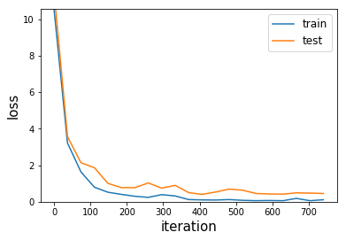

```
Accuracy_trainset : 99.8%
Accuracy_testset : 84.2%
```

```python
n_iter = 750
n_prt = n_iter//20

loss_record_train = []
loss_record_test = []
for epoch in range(n_iter+1):
    train_x, train_y = mnist.train.next_batch(n_batch)
    train_x = np.reshape(train_x, [-1, input_h, input_w, input_ch])
    sess.run(optm_10_2, feed_dict = {x: train_x,  y_10: train_y})

    if epoch % n_prt == 0:
        test_x, test_y = mnist.test.next_batch(n_batch)
        test_x = np.reshape(test_x, [-1, input_h, input_w, input_ch])
        c1 = sess.run(loss_10_2, feed_dict = {x: train_x, y_10: train_y})
        c2 = sess.run(loss_10_2, feed_dict = {x: test_x, y_10: test_y})
        loss_record_train.append(c1)
        loss_record_test.append(c2)
        print ("({:04d}/{:04d}) loss_train: {:.6f}, loss_test: {:.6f}".format(epoch, n_iter, c1, c2))

plt.plot(np.arange(len(loss_record_train))*n_prt, loss_record_train, label = 'train')
plt.plot(np.arange(len(loss_record_test))*n_prt, loss_record_test, label = 'test')
plt.xlabel('iteration', fontsize = 15)
plt.ylabel('loss', fontsize = 15)
plt.legend(fontsize = 12)
plt.ylim([0, np.max(loss_record_train)])
plt.show()

my_pred = sess.run(pred_10_2, feed_dict = {x: mnist.train.images.reshape(-1, 28, 28, 1)})
accr = np.mean(np.equal(np.argmax(my_pred, axis = 1), np.argmax(mnist.train.labels, axis = 1)))
print("Accuracy_trainset : {:.1f}%".format(accr*100))

my_pred = sess.run(pred_10_2, feed_dict = {x: mnist.test.images.reshape(-1, 28, 28, 1)})
accr = np.mean(np.equal(np.argmax(my_pred, axis = 1), np.argmax(mnist.test.labels, axis = 1)))
print("Accuracy_testset : {:.1f}%".format(accr*100))
```

# Problem 2: Sign Language Image by CNN and CAE

In this problem, we are going to implement CNN and CAE models to classify sign language images.

Download data from [here](https://www.dropbox.com/s/03d30bl0k6f9bqm/sign_language.zip?dl=1)

```python
import numpy as np
import matplotlib.pyplot as plt
import tensorflow as tf
from six.moves import cPickle
```

(1) Load the below sign language image data and check the shape of each image.

- sign_language_train_img.pkl
- sign_language_test_img.pkl
- sign_language_train_label.pkl
- sign_language_test_label.pkl

```python
train_imgs = cPickle.load(open('./data_files/sign_language_train_img.pkl', 'rb'))
train_labels = cPickle.load(open('./data_files/sign_language_train_label.pkl', 'rb'))
test_imgs = cPickle.load(open('./data_files/sign_language_test_img.pkl', 'rb'))
test_labels = cPickle.load(open('./data_files/sign_language_test_label.pkl', 'rb'))
```

```python
train_imgs[0].shape
```

```
(100, 100)
```

**CNN Model**

(2) Design your CNN model.

- input shape
- output shape
- hidden layers
- placeholder
- loss and optimizer

```python
# Your code here
input_h = 100
input_w = 100
input_ch = 1

k1_h = 3
k1_w = 3
k1_ch = 16
p1_h = 2
p1_w = 2

k2_h = 3
k2_w = 3
k2_ch = 16
p2_h = 2
p2_w = 2

conv_result_size = int(input_h/(2**2)) * int(input_w/(2**2)) * k2_ch
n_hidden = 100
n_output = 6
```

```python
weights = {
    'conv1' : tf.get_variable(name = 'w_conv1',
                              shape = [k1_h, k1_w, input_ch, k1_ch],
                              initializer = tf.contrib.layers.xavier_initializer()),
    'conv2' : tf.get_variable(name = 'w_conv2',
                              shape = [k2_h, k2_w, k1_ch, k2_ch],
                              initializer = tf.contrib.layers.xavier_initializer()),
    'hidden' : tf.get_variable(name = 'w_hidden',
                               shape = [conv_result_size, n_hidden],
                               initializer = tf.contrib.layers.xavier_initializer()),
    'output' : tf.get_variable(name = 'w_output',
                               shape = [n_hidden, n_output],
                               initializer = tf.contrib.layers.xavier_initializer())
}

biases = {
    'conv1' : tf.get_variable(name = 'b_conv1',
                              shape = [k1_ch],
                              initializer = tf.contrib.layers.xavier_initializer()),
    'conv2' : tf.get_variable(name = 'b_conv2',
                              shape = [k2_ch],
                              initializer = tf.contrib.layers.xavier_initializer()),
    'hidden' : tf.get_variable(name = 'b_hidden',
                               shape = [n_hidden],
                               initializer = tf.contrib.layers.xavier_initializer()),
    'output' : tf.get_variable(name = 'b_output',
                               shape = [n_output],
                               initializer = tf.contrib.layers.xavier_initializer())
}

x = tf.placeholder(tf.float32, [None, input_h, input_w, input_ch], name = 'input_img')
y = tf.placeholder(tf.float32, [None, n_output], name = 'input_label')
```

```python
def net(x, weights, biases):
    conv1 = tf.nn.conv2d(x, weights['conv1'], strides= [1, 1, 1, 1], padding = 'SAME')
    conv1 = tf.nn.relu(tf.add(conv1, biases['conv1']))
    maxp1 = tf.nn.max_pool(conv1, ksize = [1, p1_h, p1_w, 1], strides = [1, p1_h, p1_w, 1], padding = 'VALID', name = 'maxp1')

    conv2 = tf.nn.conv2d(maxp1, weights['conv2'], strides= [1, 1, 1, 1], padding = 'SAME')
    conv2 = tf.nn.relu(tf.add(conv2, biases['conv2']))
    maxp2 = tf.nn.max_pool(conv2, ksize = [1, p2_h, p2_w, 1], strides = [1, p2_h, p2_w, 1], padding = 'VALID', name = 'maxp1')

    maxp2_re = tf.reshape(maxp2, [-1, conv_result_size])

    hidden = tf.add(tf.matmul(maxp2_re, weights['hidden']), biases['hidden'])
    hidden = tf.nn.relu(hidden)

    score = tf.add(tf.matmul(hidden, weights['output']), biases['output'], name= 'score')

    return score
```

```python
score = net(x, weights, biases)
loss = tf.nn.softmax_cross_entropy_with_logits_v2(labels=y, logits=score)
loss = tf.reduce_mean(loss)

LR = 1e-4
optm = tf.train.AdamOptimizer(LR).minimize(loss)
init = tf.global_variables_initializer()
```

```python
n_batch = 10
n_iter = 10000
n_prt = 1000
```

(3) Train and test your model.

- Note: you should calculate test accuracy

```python
# Your code here

sess = tf.Session()
sess.run(init)

# Training cycle
for epoch in range(n_iter):
    idx = np.random.randint(len(train_labels), size=n_batch)
    train_x = [train_imgs[i] for i in idx]
    train_y = [train_labels[i] for i in idx]
    train_x = np.reshape(np.array(train_x),(-1,100,100,1))
    sess.run(optm, feed_dict={x: train_x,  y: train_y})

    if epoch % n_prt == 0:
        c = sess.run(loss, feed_dict={x: train_x, y: train_y})
        print ("Iter : {}".format(epoch))
        print ("Cost : {}".format(c))
```

```
Iter : 0
Cost : 17.795368194580078
Iter : 1000
Cost : 0.0007051863358356059
Iter : 2000
Cost : 4.153017289354466e-05
Iter : 3000
Cost : 0.00010801133612403646
Iter : 4000
Cost : 0.00026161110145039856
Iter : 5000
Cost : 0.0001146024078479968
Iter : 6000
Cost : 8.46992916194722e-05
Iter : 7000
Cost : 7.8191704233177e-05
Iter : 8000
Cost : 7.045102393021807e-06
Iter : 9000
Cost : 1.605710895091761e-05
```

```python
size = 100
idx = np.random.randint(len(test_labels), size=size)
test_x = [test_imgs[i] for i in idx]
test_y = [test_labels[i] for i in idx]

my_pred = sess.run(score, feed_dict={x : np.array(test_x).reshape(-1,100,100,1)})
my_pred = np.argmax(my_pred, axis=1)

labels = np.argmax(test_y, axis=1)

accr = np.mean(np.equal(my_pred, labels))
print("Accuracy : {}%".format(accr*100))
```

```
Accuracy : 81.0%
```

**CAE Model**

(4) Define your CAE model.

- input
- output
- placeholder
- encoder
  - three convolution layers
  - convolution + pooling + convolution + pooling + convolution
  - conv1 : filter = 32, kernel size = [3,3]
  - conv2 : filter = 64, kernel size = [3,3]
  - conv3 : filter = 10, kernel size = [25,25]
- latent : (1,1,10)
- decoder: inverse shape of encoder
- loss and optimizer

```python
# Input
input_h = 100
input_w = 100
input_ch = 1

## Output
output_h = 100
output_w = 100
output_ch = 1
```

```python
x = tf.placeholder(tf.float32, [None, input_h, input_w, input_ch])
y = tf.placeholder(tf.float32, [None, output_h, output_w, output_ch])
```

```python
def encoder(x):
    ## First convolution layer
    conv1 = tf.layers.conv2d(inputs = x,
                             filters = 32,
                             kernel_size = [3, 3],
                             strides = [1, 1],
                             padding = "SAME",
                             activation = tf.nn.relu)
    maxp1 = tf.layers.max_pooling2d(inputs = conv1,
                                    pool_size = [2, 2],
                                    strides = 2)

    ## Second convolution layer
    conv2 = tf.layers.conv2d(inputs = maxp1,
                             filters = 64,
                             kernel_size = [3, 3],
                             padding = "SAME",
                             activation = tf.nn.relu)
    maxp2 = tf.layers.max_pooling2d(inputs = conv2,
                                    pool_size = [2, 2],
                                    strides = 2)

    conv3 = tf.layers.conv2d(inputs = maxp2,
                             filters = 10,
                             kernel_size = [25, 25],
                             padding = "VALID")

    return conv3
```

```python
def decoder(latent):
    deconv3 = tf.layers.conv2d_transpose(inputs = latent,
                                         filters = 64,
                                         kernel_size = [25, 25],
                                         padding = 'VALID',
                                         activation = tf.nn.relu)

    ## First deconvolution layer
    deconv2 = tf.layers.conv2d_transpose(inputs = deconv3,
                                         filters = 32,
                                         kernel_size = [3, 3],
                                         strides = (2, 2),
                                         padding = 'SAME',
                                         activation = tf.nn.relu)

    ## Second deconvolution layer
    deconv1 = tf.layers.conv2d_transpose(inputs = deconv2,
                                         filters = 1,
                                         kernel_size = [3, 3],
                                         strides = (2, 2),
                                         padding = 'SAME')

    return deconv1
```

```python
LR = 0.0001

latent = encoder(x)
reconst = decoder(latent)
loss = tf.square(tf.subtract(x, reconst))
loss = tf.reduce_mean(loss)

optm = tf.train.AdamOptimizer(LR).minimize(loss)
```

[output not shown]

```python
def train_batch_maker(batch_size):
    random_idx = np.random.randint(n_train, size = batch_size)
    return np.reshape(np.array(train_imgs)[random_idx], (-1, 100, 100, 1)), np.array(train_labels)[random_idx]

def test_batch_maker(batch_size):
    random_idx = np.random.randint(n_test, size = batch_size)
    return np.reshape(np.array(test_imgs)[random_idx],(-1, 100, 100, 1)), np.array(test_labels)[random_idx]
```

(5) Train your model and plot train and test loss.

```python
n_train = len(train_imgs)
n_test = len(test_imgs)

n_batch = 50
n_iter = 5000
n_prt = 250

sess = tf.Session()
init = tf.global_variables_initializer()
sess.run(init)

loss_record_train = []
loss_record_test = []
for epoch in range(n_iter):
    train_x, _ = train_batch_maker(n_batch)
    sess.run(optm, feed_dict = {x: train_x})

    if epoch % n_prt == 0:
        test_x, _ = test_batch_maker(n_batch)
        c1 = sess.run(loss, feed_dict = {x: train_x})
        c2 = sess.run(loss, feed_dict = {x: test_x})
        loss_record_train.append(c1)
        loss_record_test.append(c2)
        print ("Iter : {}".format(epoch))
        print ("Cost : {}".format(c1))
```

```
Iter : 0
Cost : 29535.154296875
Iter : 250
Cost : 1209.02490234375
Iter : 500
Cost : 1091.89990234375
Iter : 750
Cost : 1080.5992431640625
Iter : 1000
Cost : 1099.1387939453125
Iter : 1250
Cost : 961.62158203125
Iter : 1500
Cost : 897.72119140625
Iter : 1750
Cost : 721.9996948242188
Iter : 2000
Cost : 706.3238525390625
Iter : 2250
Cost : 716.5584106445312
Iter : 2500
Cost : 757.8984985351562
Iter : 2750
Cost : 662.6260986328125
Iter : 3000
Cost : 625.84423828125
Iter : 3250
Cost : 603.6865234375
Iter : 3500
Cost : 629.3356323242188
Iter : 3750
Cost : 537.0018920898438
Iter : 4000
Cost : 583.3447265625
Iter : 4250
Cost : 593.3798828125
Iter : 4500
Cost : 558.05322265625
Iter : 4750
Cost : 545.1952514648438
```

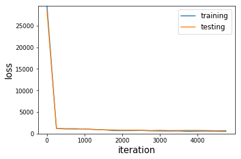

```python
plt.plot(np.arange(len(loss_record_train))*n_prt, loss_record_train, label = 'training')
plt.plot(np.arange(len(loss_record_test))*n_prt, loss_record_test, label = 'testing')
plt.xlabel('iteration', fontsize = 15)
plt.ylabel('loss', fontsize = 15)
plt.legend(fontsize = 12)
plt.ylim([0, np.max(loss_record_train)])
plt.show()
```

(6) Test your CAE model by reconstuct randomly selected image. Plot and compare an input image to the reconstructed image.

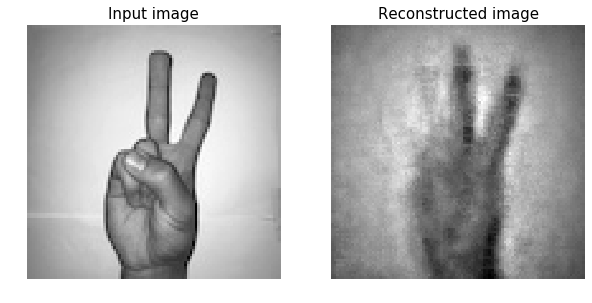

```python
test_x, _ = test_batch_maker(1)
test_x = np.reshape(test_x, [-1, input_h, input_w, input_ch])
x_reconst = sess.run(reconst, feed_dict = {x: test_x})

plt.figure(figsize = (10,8))
plt.subplot(1,2,1)
plt.imshow(test_x.reshape(100,100), 'gray')
plt.title('Input image', fontsize = 15)
plt.axis('off')
plt.subplot(1,2,2)
plt.imshow(x_reconst.reshape(100,100), 'gray')
plt.title('Reconstructed image', fontsize = 15)
plt.axis('off')
plt.show()
```

(7) We learned from class that the autoencoder compresses as much information as possible in a smaller representation. Apply logistc regrsssion model to latent space and calculate test accuracy.

$\;\;\,$ Note: test accuracy should be higher than 75%

```python
from sklearn import linear_model

train_x, train_y = train_batch_maker(500)
train_x = np.reshape(train_x, [-1, input_h, input_w, input_ch])
train_latent = sess.run(latent, feed_dict = {x: train_x})
clf = linear_model.LogisticRegression(solver = 'lbfgs')
clf.fit(train_latent.reshape(500,10), np.ravel(np.argmax(train_y, axis = 1)))
```

```
LogisticRegression(C=1.0, class_weight=None, dual=False, fit_intercept=True,
                   intercept_scaling=1, l1_ratio=None, max_iter=100,
                   multi_class='warn', n_jobs=None, penalty='l2',
                   random_state=None, solver='lbfgs', tol=0.0001, verbose=0,
                   warm_start=False)
```

```python
test_x, test_y = test_batch_maker(100)
test_x = np.reshape(test_x, [-1, input_h, input_w, input_ch])
test_latent = sess.run(latent, feed_dict={x : test_x})
test_latent = test_latent.reshape(100,10)
pred = clf.predict(test_latent)
acc = np.mean(np.equal(pred, np.argmax(test_y, axis = 1)))
print('Accuracy : {}%'.format(acc*100))
```

```
Accuracy : 76.0%
```